# CS 613 - Machine Learning

# Assignment 3 - Dimensionality Reduction & Clustering

Name  
CS 613 Machine Learning  
Fall 2021  
Dr. Edward Kim  
Drexel University

# Introduction

In this assignment you'll work on visualizing data, reducing its dimensionality and clustering it.

You may not use any functions from machine learning library in your code, however you may use statistical functions. For example, if available you **MAY NOT** use functions like:

- pca
- k-nearest neighbors functions

Unless explicitly told to do so.

But you **MAY** use basic statistical functions like:

- std
- mean
- cov
- eig
- svd

# Submission

For your submission, upload to Blackboard a single zip file containing:

1. A LaTeX typeset PDF or Jupyter Notebook PDF containing:

   *(a)* Part 1: Your answers to the theory questions.

   1.2b.

   1.2e

[figure not shown]

   *(b)* Part 2: The visualization of the PCA result, KNN accuracies.

   KNN score, k=1, no PCA: 0.23255813953488372  
   KNN score, k=1, PCA100: 0.25775193798449614  
   KNN score whitened: 0.3546511627906977  
   Project PCA2 (image):

[figure not shown]

   *(c)* Part 3:

   i.  
   Minimum face on PC1 axis

[figure not shown]

   Maximum face on PC1 axis

[figure not shown]

   Minimum face on PC2 axis

[figure not shown]

   Maximum face on PC2 axis

[figure not shown]

   Principle component reconstruction

[figure not shown]

   ii. Number of principle components needed to represent 95% of information, $k$: 197

   iii.

   Original image

[figure not shown]

   Single principle component

[figure not shown]

   197 principle components

[figure not shown]

   *(d)* Part 4:

   *(e)* Source Code - python notebook

```python
import pandas as pd
import numpy as np
import random
import matplotlib.pyplot as plt
import numpy.matlib
from sklearn.preprocessing import scale
from sklearn.decomposition import PCA
from sklearn.metrics import accuracy_score
from scipy.spatial.distance import cdist
```

# DataSets

Labeled Faces in the Wild Dataset. This dataset consists of celebrities download from the Internet from the early 2000s. We use the grayscale version from sklearn.datasets. We will download the images in a specific way as shown below. You will have 3,023 images, each 87x65 pixels large, belonging to 62 different people.

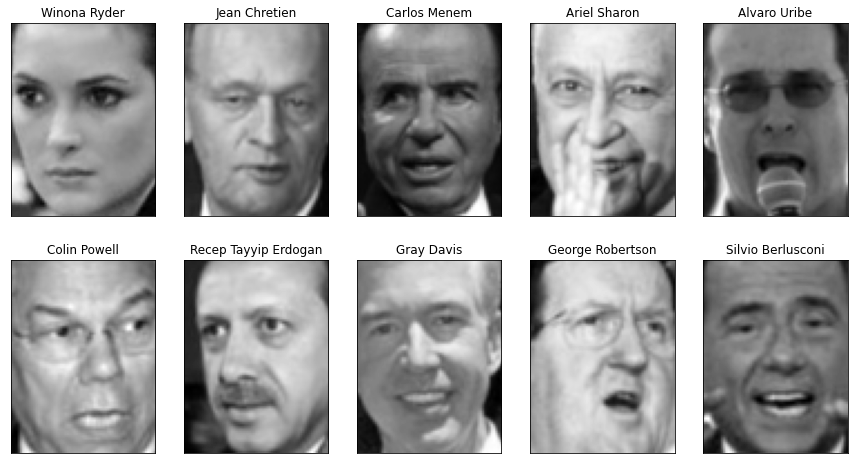

```python
from sklearn.datasets import fetch_lfw_people
import matplotlib.pyplot as plt
import matplotlib.cm as cm

people = fetch_lfw_people(min_faces_per_person=20, resize=0.7)
image_shape = people.images[0].shape

fig, axes = plt.subplots(2, 5, figsize=(15, 8),
                         subplot_kw={'xticks': (), 'yticks': ()})
for target, image, ax in zip(people.target, people.images, axes.ravel()):
    ax.imshow(image, cmap=cm.gray)
    ax.set_title(people.target_names[target])
```

# Part 1: Theory Questions

## 1.1 Consider the following data:

```python
x1 = [-2., -5., -3., 0., -8., -2., 1., 5., -1., 6.]
x2 = [1., -4., 1., 3., 11., 5., 0, -1., -3., 1.]
theory_data1 = pd.DataFrame({
    'x1': x1,
    'x2': x2
})
theory_data1
```

|  | x1 | x2 |
| --- | --- | --- |
| 0 | -2.0 | 1.0 |
| 1 | -5.0 | -4.0 |
| 2 | -3.0 | 1.0 |
| 3 | 0.0 | 3.0 |
| 4 | -8.0 | 11.0 |
| 5 | -2.0 | 5.0 |
| 6 | 1.0 | 0.0 |
| 7 | 5.0 | -1.0 |
| 8 | -1.0 | -3.0 |
| 9 | 6.0 | 1.0 |

a. Find the principle components of the data (you must show the math, including how you compute the eivenvectors and eigenvalues). Make sure you standardize the data first and that your principle components are normalized to be unit length. As for the amount of detail needed in your work imagine that you were working on paper with a basic calculator. Show me whatever you would be writing on that paper. (5pts)

b. Project the data onto the principal component corresponding to the largest eigenvalue found in the previous part (3pts)

## 1.2. Consider the following data

```python
x1 = [-2., -5., -3., 0., -8., -2., 1., 5., -1., 6.]
x2 = [1., -4., 1., 3., 11., 5., 0, -1., -3., 1.]
y = [0, 0, 0, 0, 0, 1, 1, 1, 1, 1]
td2 = pd.DataFrame({
    'x1': x1,
    'x2': x2,
    'y': y,
    'Count': 1
})
```

```python
td2.groupby(['y', 'x1', 'x2']).first()
```

| y | x1 | x2 | Count |
| --- | --- | --- | --- |
| 0 | -8.0 | 11.0 | 1 |
|  | -5.0 | -4.0 | 1 |
|  | -3.0 | 1.0 | 1 |
|  | -2.0 | 1.0 | 1 |
|  | 0.0 | 3.0 | 1 |
| 1 | -2.0 | 5.0 | 1 |
|  | -1.0 | -3.0 | 1 |
|  | 1.0 | 0.0 | 1 |
|  | 5.0 | -1.0 | 1 |
|  | 6.0 | 1.0 | 1 |

(a) Compute the information gain for each feature. You could standardize the data overall, although it won’t make a difference. (5pts).

(b) Which feature is more discriminating based on results in part a (1pt)?

(c) Using LDA, find the direction of projection (you must show the math, however for this one you don’t have to show the computation for finding the eigenvalues and eigenvectors). Normalize this vector to be unit length (5pts).

(d) Project the data onto the principal component found in the previous part (3pts).

(e) Does the projection you performed in the previous part seem to provide good class separation? Why or why not (1pt)?

# Part 2: Dimensionality Reduction via PCA

Import the data as shown above. This the labeled faces in the wild dataset. Verify that you have the correct number of people and classes

```python
print("people.images.shape: {}".format(people.images.shape))
print("Number of classes: {}".format(len(people.target_names)))
```

```
people.images.shape: (3023, 87, 65)
Number of classes: 62
```

This dataset is skewed toward George W. Bush and Colin Powell as you can verify here:

```python
# count how often each target appears
counts = np.bincount(people.target)
# print counts next to target names
for i, (count, name) in enumerate(zip(counts, people.target_names)):
    print("{0:25} {1:3}".format(name, count), end='   ')
    if (i + 1) % 3 == 0:
        print()
```

```
Alejandro Toledo           39   Alvaro Uribe               35   Amelie Mauresmo            21
Andre Agassi               36   Angelina Jolie             20   Ariel Sharon               77
Arnold Schwarzenegger      42   Atal Bihari Vajpayee       24   Bill Clinton               29
Carlos Menem               21   Colin Powell              236   David Beckham              31
Donald Rumsfeld           121   George Robertson           22   George W Bush             530
Gerhard Schroeder         109   Gloria Macapagal Arroyo    44   Gray Davis                 26
Guillermo Coria            30   Hamid Karzai               22   Hans Blix                  39
Hugo Chavez                71   Igor Ivanov                20   Jack Straw                 28
Jacques Chirac             52   Jean Chretien              55   Jennifer Aniston           21
Jennifer Capriati          42   Jennifer Lopez             21   Jeremy Greenstock          24
Jiang Zemin                20   John Ashcroft              53   John Negroponte            31
Jose Maria Aznar           23   Juan Carlos Ferrero        28   Junichiro Koizumi          60
Kofi Annan                 32   Laura Bush                 41   Lindsay Davenport          22
Lleyton Hewitt             41   Luiz Inacio Lula da Silva  48   Mahmoud Abbas              29
Megawati Sukarnoputri      33   Michael Bloomberg          20   Naomi Watts                22
Nestor Kirchner            37   Paul Bremer                20   Pete Sampras               22
Recep Tayyip Erdogan       30   Ricardo Lagos              27   Roh Moo-hyun               32
Rudolph Giuliani           26   Saddam Hussein             23   Serena Williams            52
Silvio Berlusconi          33   Tiger Woods                23   Tom Daschle                25
Tom Ridge                  33   Tony Blair                144   Vicente Fox                32
Vladimir Putin             49   Winona Ryder               24
```

To make the data less skewed, we will only take up to 50 images of each person (otherwise, the feature extraction would be overwhelmed by the likelihood of George W. Bush):

```python
mask = np.zeros(people.target.shape, dtype=np.bool)
for target in np.unique(people.target):
    mask[np.where(people.target == target)[0][:50]] = 1

X_people = people.data[mask]
y_people = people.target[mask]

# scale the grayscale values to be between 0 and 1
# instead of 0 and 255 for better numeric stability
X_people = X_people / 255.
```

We are now going to compute how well a KNN classifier does using just the pixels alone.

```python
from sklearn.neighbors import KNeighborsClassifier
from sklearn.model_selection import train_test_split
# split the data into training and test sets
X_train, X_test, y_train, y_test = train_test_split(X_people, y_people, stratify=y_people, random_state=0)
# build a KNeighborsClassifier using one neighbor
knn = KNeighborsClassifier(n_neighbors=1)
knn.fit(X_train, y_train)
print("Test set score of 1-nn: {:.10f}".format(knn.score(X_test, y_test)))
```

```
Test set score of 1-nn: 0.2325581395
```

You should have an accuracy around 23\% - 27\%.

**Once you have your setup complete, write a script to do the following:**

1. Write your own version of KNN (k=1) where you use the SSD (sum of squared differences) to compute similarity
2. Verify that your KNN has a similar accuracy as sklearn’s version
3. Standardize your data (zero mean, divide by standard deviation)
4. Reduces the data to 100D using PCA
5. Compute the KNN again where K=1 with the 100D data. Report the accuracy
6. Compute the KNN again where K=1 with the 100D Whitened data. Report the accuracy
7. Reduces the data to 2D using PCA
8. Graphs the data for visualization

Recall that although you may not use any package ML functions like *pca*, you may use statistical functions like *eig* or *svd*.

Your graph should end up looking similar to Figure 1 *refer to the PDF for the figure* (although it may be rotated differently, de-pending how you ordered things)

```python
##
## Problem 2
##

import pandas as pd
import numpy as np
import random
import matplotlib.pyplot as plt
import numpy.matlib
from sklearn.preprocessing import scale
from sklearn.decomposition import PCA
from sklearn.metrics import accuracy_score
from scipy.spatial.distance import cdist
from scipy.spatial import distance

from sklearn.datasets import fetch_lfw_people
import matplotlib.pyplot as plt
import matplotlib.cm as cm

people = fetch_lfw_people(min_faces_per_person=20, resize=0.7)
image_shape = people.images[0].shape

#fig, axes = plt.subplots(2, 5, figsize=(15, 8),
#                         subplot_kw={'xticks': (), 'yticks': ()})
#for target, image, ax in zip(people.target, people.images, axes.ravel()):
#    ax.imshow(image, cmap=cm.gray)
#    ax.set_title(people.target_names[target])

#print("people.images.shape: {}".format(people.images.shape))
#print("Number of classes: {}".format(len(people.target_names)))

# count how often each target appears
counts = np.bincount(people.target)
# print counts next to target names
#for i, (count, name) in enumerate(zip(counts, people.target_names)):
#    print("{0:25} {1:3}".format(name, count), end='   ')
#    if (i + 1) % 3 == 0:
#        print()

mask = np.zeros(people.target.shape, dtype=np.bool)
for target in np.unique(people.target):
    mask[np.where(people.target == target)[0][:50]] = 1

X_people = people.data[mask]
y_people = people.target[mask]

# scale the grayscale values to be between 0 and 1
# instead of 0 and 255 for better numeric stability
X_people = X_people / 255.

from sklearn.neighbors import KNeighborsClassifier
from sklearn.model_selection import train_test_split
# split the data into training and test sets
X_train, X_test, y_train, y_test = train_test_split(X_people, y_people, stratify=y_people, random_state=0)
# build a KNeighborsClassifier using one neighbor
knn = KNeighborsClassifier(n_neighbors=1)
knn.fit(X_train, y_train)
print("Test set score of 1-nn: {:.10f}".format(knn.score(X_test, y_test)))
```

```
Test set score of 1-nn: 0.2325581395
```

```python
##
## Problem 2 continued
##




predictions = np.zeros(np.shape(y_test))

def K_Nearest_Neighbors(X_train,y_train,X_test,y_test,d=100):
    correct = 0
    for i in range(np.shape(X_test)[0]):
        dist = np.zeros(np.shape(y_train))
        for j in range(np.shape(X_train)[0]):
            dist[j] = distance.euclidean(X_test[i,:],X_train[j,:])
        predictions[i] = y_train[np.argmin(dist)]
        if predictions[i] == y_test[i]:
            correct += 1
    accuracy = correct / np.shape(predictions)[0]
    return accuracy

accuracy = K_Nearest_Neighbors(X_train,y_train,X_test,y_test)
print(accuracy)
```

```
0.23255813953488372
```

```python
##
## Problem 2 continued
##

# standardize data
mean = np.mean(X_people, axis=0)
std = np.std(X_people, axis=0, ddof=1)
sX_people = (X_people-mean)/std

# Reduce dimensionality using PCA
N = sX_people.shape[1]
sigma = (sX_people.T @ sX_people) / (N - 1)
val, vec = np.linalg.eig(sigma)
```

```python
#print(val)
#print(vec)

#choose the 100 eigenvectors with the highest eigenvalues
# val list is already sorted in ascending order
# get last 100 values in np array
sorted_index = np.argsort(val)[::-1]

sorted_eigenvalue = val[sorted_index]
sorted_eigenvectors = vec[:,sorted_index]

number_of_components = 100
eigenvector_subset = sorted_eigenvectors[:,0:number_of_components]
```

```python
# transform the data
X_reduced = np.dot(eigenvector_subset.transpose(),sX_people.transpose()).transpose()
```

```python
# test dimensionality reduction on KNN
X_train2, X_test2, y_train2, y_test2 = train_test_split(X_reduced, y_people, stratify=y_people, random_state=0)
accuracy = K_Nearest_Neighbors(X_train2,y_train2,X_test2,y_test2)
print(accuracy)
```

```
0.25775193798449614
```

```python
## whiten the data
X_mat = sX_people.T
y = sorted_eigenvectors[:,0:100].T @ X_mat
z = np.diag(np.abs(sorted_eigenvalue[0:100])**(-1/2)) @ y
```

```python
# run KNN on whitened data
print(z.shape)
print(X_reduced.shape)
X_train3, X_test3, y_train3, y_test3 = train_test_split(z.T, y_people, stratify=y_people, random_state=0)
accuracy = K_Nearest_Neighbors(X_train3,y_train3,X_test3,y_test3)
print(accuracy)
```

```
(100, 2063)
(2063, 100)
0.3546511627906977
```

```python
# reduce the data to 2D
two_dimensional_data = sorted_eigenvectors[:,0:2].T @ X_mat
```

```
(2, 2063)
```

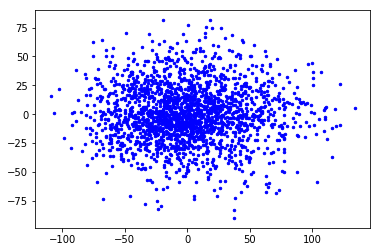

```python
# plot 2D data
print(two_dimensional_data.shape)
plt.scatter(two_dimensional_data[0],two_dimensional_data[1],s=6,c='b')
plt.show()
```

# Part 3: Eigenfaces

Import the data as shown above. This the labeled faces in the wild dataset.Use the Xtrain data from above. Let’s analyze the first and second principal components.

**Write a script that:**

1. Imports the data as mentioned above.
2. Standardizes the data.
3. Performs PCA on the data (again, although you may not use any package ML functions like pca, you may use statistical functions like eig). No need to whiten here.
4. Find the max and min image on PC1’s axis. Find the max and min of PC2. Plot and report which faces these points correspond to, what variation do these components capture?
5. Visualizes the most important principle component as a 87x65 image (see Figure 2).
6. Reconstructs the Xtrain[0,:] image using the primary principle component. To best see the full reconstruction, “unstandardize” the reconstruction by multiplying it by the original standard deviation and adding back in the original mean.
7. Determines the number of principle components necessary to encode at least 95% of the information, k.
8. Reconstructs theXtrain[0,:]image using the k most significant eigen-vectors (found in theprevious step, see Figure 4). For the fun of it maybe even look to see if you can perfectly reconstruct the face if you use all the eigen-vectors! Again, to best see the full re-construction,“unstandardize” the reconstruction by multiplying it by the original standard deviation andadding back in the original mean.

Your principle eigenface should end up looking similar to Figure 2 of the PDF.

Your principal reconstruction should end up looking similar to Figure 3 of the PDF.

Your 95% reconstruction should end up looking similar to Figure 4 of the PDF.

```
(2, 2063)
```

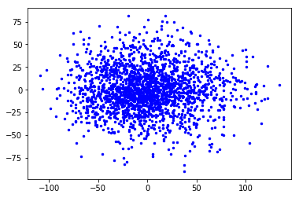

```python
##
## Problem 3
##

import pandas as pd
import numpy as np
import random
import matplotlib.pyplot as plt
import numpy.matlib
from sklearn.preprocessing import scale
from sklearn.decomposition import PCA
from sklearn.metrics import accuracy_score
from scipy.spatial.distance import cdist
from scipy.spatial import distance

from sklearn.datasets import fetch_lfw_people
import matplotlib.pyplot as plt
import matplotlib.cm as cm

people = fetch_lfw_people(min_faces_per_person=20, resize=0.7)
image_shape = people.images[0].shape

#fig, axes = plt.subplots(2, 5, figsize=(15, 8),
#                         subplot_kw={'xticks': (), 'yticks': ()})
#for target, image, ax in zip(people.target, people.images, axes.ravel()):
#    ax.imshow(image, cmap=cm.gray)
#    ax.set_title(people.target_names[target])

#print("people.images.shape: {}".format(people.images.shape))
#print("Number of classes: {}".format(len(people.target_names)))

# count how often each target appears
counts = np.bincount(people.target)
# print counts next to target names
#for i, (count, name) in enumerate(zip(counts, people.target_names)):
#    print("{0:25} {1:3}".format(name, count), end='   ')
#    if (i + 1) % 3 == 0:
#        print()

mask = np.zeros(people.target.shape, dtype=np.bool)
for target in np.unique(people.target):
    mask[np.where(people.target == target)[0][:50]] = 1

X_people = people.data[mask]
y_people = people.target[mask]

# scale the grayscale values to be between 0 and 1
# instead of 0 and 255 for better numeric stability
X_people = X_people / 255.

# standardize data
mean = np.mean(X_people, axis=0)
std = np.std(X_people, axis=0, ddof=1)
sX_people = (X_people-mean)/std
X_mat = sX_people.T

# Reduce dimensionality using PCA
N = sX_people.shape[1]
sigma = (sX_people.T @ sX_people) / (N - 1)
val, vec = np.linalg.eig(sigma)

#choose the eigenvectors with the highest eigenvalues
# val list is already sorted in ascending order
sorted_index = np.argsort(val)[::-1]

sorted_eigenvalue = val[sorted_index]
sorted_eigenvectors = vec[:,sorted_index]

number_of_components = 2
eigenvector_subset = sorted_eigenvectors[:,0:number_of_components]

# reduce the data to 2D
two_dimensional_data = sorted_eigenvectors[:,0:2].T @ X_mat

# plot 2D data
print(two_dimensional_data.shape)
plt.scatter(two_dimensional_data[0],two_dimensional_data[1],s=6,c='b')
plt.show()
```

```python
# Find min and max images on PC axes
PC1 = two_dimensional_data[0].tolist()
PC2 = two_dimensional_data[1].tolist()
min_PC1 = min(PC1)
max_PC1 = max(PC1)
min_PC2 = min(PC2)
max_PC2 = max(PC2)
index_min_PC1 = PC1.index(min_PC1)
index_max_PC1 = PC1.index(max_PC1)
index_min_PC2 = PC2.index(min_PC2)
index_max_PC2 = PC2.index(max_PC2)
print(index_min_PC1)
print(index_max_PC1)
print(index_min_PC2)
print(index_max_PC2)
print(y_people[index_min_PC1])
print(y_people[index_max_PC1])
print(y_people[index_min_PC2])
print(y_people[index_max_PC2])

print(X_people[11].shape)
```

```
1425
1105
590
11
13
36
18
14
(5655,)
```

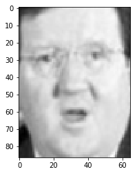

```python
# plot faces

#people = fetch_lfw_people(min_faces_per_person=20, resize=0.7)
#image_shape = people.images[0].shape

#fig, axes = plt.subplots(2, 2, figsize=(15, 8),
#                         subplot_kw={'xticks': (), 'yticks': ()})
#for target, image, ax in zip(people.target, people.images, axes.ravel()):
#    ax.imshow(image, cmap=cm.gray)
#    ax.set_title(people.target_names[target])

plt.imshow(np.reshape(X_people[1425],(87,65)), cmap=cm.gray)
plt.show()
```

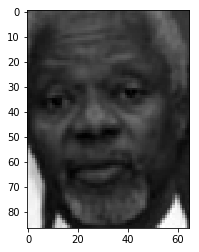

```python
plt.imshow(np.reshape(X_people[1105],(87,65)), cmap=cm.gray)
plt.show()
```

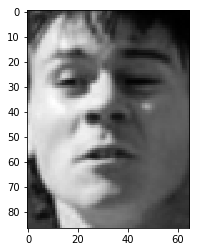

```python
plt.imshow(np.reshape(X_people[590],(87,65)), cmap=cm.gray)
plt.show()
```

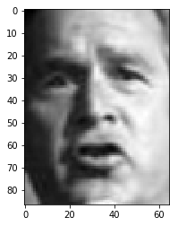

```python
plt.imshow(np.reshape(X_people[11],(87,65)), cmap=cm.gray)
plt.show()
```

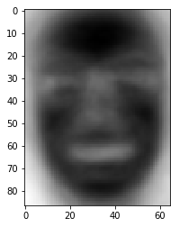

```python
## Problem 3 Part 5

plt.imshow(np.reshape(sorted_eigenvectors[:,0],(87,65)), cmap=cm.gray)
plt.show()
```

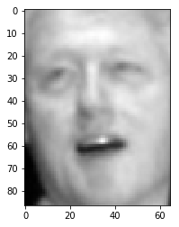

```python
plt.imshow(np.reshape(X_train[0,:],(87,65)), cmap=cm.gray)
plt.show()
```

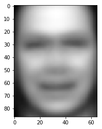

```python
##
## Problem 3 Part 6
##

# reconstruct
#one_dimensional = sorted_eigenvectors[:,0] * X_train[0,:]
#print(one_dimensional.shape)

Z = np.array(X_train@sorted_eigenvectors[:,:1])

final = Z @ sorted_eigenvectors[:,:1].T

reconstruction = (final[0,:] * std) + mean
#reconstruction = final[0,:]

plt.imshow(np.reshape(reconstruction,(87,65)), cmap=cm.gray)
plt.show()
```

```python
##
## Problem 3 Part 7
##

total = np.sum(sorted_eigenvalue)
fraction_of_variance = 0
k = 0
for value in sorted_eigenvalue:
    fraction_of_variance += value/total
    if fraction_of_variance <= 0.95:
        k += 1
        #print(fraction_of_variance)
k += 1
print(k)
```

```
197
```

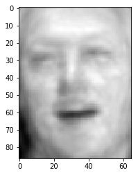

```python
##
## Problem 3 Part 8
##

# reconstruct

Zk = np.array(X_train@sorted_eigenvectors[:,:k])

finalk = Zk @ sorted_eigenvectors[:,:k].T

#reconstruction = (final[0,:] * std) + mean
reconstructionk = finalk[0,:]

plt.imshow(np.reshape(reconstructionk,(87,65)), cmap=cm.gray)
plt.show()
```

# Part 4: Clustering

Let’s implement our own version of k-means to cluster data! Once you have your setup complete as shown above , write a script to do the following:

1. Write your own version of K-means clustering where you use the L2 distance to compute similarity
2. Standardize your data (zero mean, divide by standard deviation)
3. Reduces the data to 100D using PCA.
4. Run K-means clustering with K = 10.
5. Report the number of images within each cluster.
6. Reconstruct the cluster centers for each of the K clusters. You will have to rotate the cluster centers back to the original space to visualize. Report these images.
7. Find the image closest to the cluster center, and furthest from the cluster center and report these images. Again, you will have to rotate the images centers back to the original space to visualize.

**Implementation Details**

1. Seed your random number generator with zero (do this right before running your k-means).
2. Randomly select k observations and use them for the initial reference vectors. I suggest you use randomize the indices and use the first k randomized indices to select the observations.
3. Use the L2 distance (Euclidean) to measure the distance between observations and reference vectors.
4. Terminate the training process when the sum of magnitude of change of the cluster centers (from the previous iteration to the current one) is less than $\epsilon=2^{-23}$. That is, when $\sum_{i=1}^k d(a_i(t-1),a_i(t))<\epsilon$ where $k$ is the number of clusters, $a_i(t)$ is the reference vector for cluster $i$ at time $t$ and $d(x,y)$ is the L1 distance (Manhattan) between vectors $x$ and $y$ (as defined in the *Similarity and Distance Functions* link on BBlearn), or when you've hit 10,000 iterations.

```python
##
## Problem 4
##

import pandas as pd
import numpy as np
import random
import matplotlib.pyplot as plt
import numpy.matlib
from sklearn.preprocessing import scale
from sklearn.decomposition import PCA
from sklearn.metrics import accuracy_score
from scipy.spatial.distance import cdist
from scipy.spatial import distance

from sklearn.datasets import fetch_lfw_people
import matplotlib.pyplot as plt
import matplotlib.cm as cm

people = fetch_lfw_people(min_faces_per_person=20, resize=0.7)
image_shape = people.images[0].shape

#fig, axes = plt.subplots(2, 5, figsize=(15, 8),
#                         subplot_kw={'xticks': (), 'yticks': ()})
#for target, image, ax in zip(people.target, people.images, axes.ravel()):
#    ax.imshow(image, cmap=cm.gray)
#    ax.set_title(people.target_names[target])

#print("people.images.shape: {}".format(people.images.shape))
#print("Number of classes: {}".format(len(people.target_names)))

# count how often each target appears
counts = np.bincount(people.target)
# print counts next to target names
#for i, (count, name) in enumerate(zip(counts, people.target_names)):
#    print("{0:25} {1:3}".format(name, count), end='   ')
#    if (i + 1) % 3 == 0:
#        print()

mask = np.zeros(people.target.shape, dtype=np.bool)
for target in np.unique(people.target):
    mask[np.where(people.target == target)[0][:50]] = 1

X_people = people.data[mask]
y_people = people.target[mask]

# scale the grayscale values to be between 0 and 1
# instead of 0 and 255 for better numeric stability
X_people = X_people / 255.

# standardize data
mean = np.mean(X_people, axis=0)
std = np.std(X_people, axis=0, ddof=1)
sX_people = (X_people-mean)/std
X_mat = sX_people.T

# Reduce dimensionality using PCA
N = sX_people.shape[1]
sigma = (sX_people.T @ sX_people) / (N - 1)
val, vec = np.linalg.eig(sigma)

#choose the eigenvectors with the highest eigenvalues
# val list is already sorted in ascending order
sorted_index = np.argsort(val)[::-1]

sorted_eigenvalue = val[sorted_index]
sorted_eigenvectors = vec[:,sorted_index]

number_of_components = 100
eigenvector_subset = sorted_eigenvectors[:,0:number_of_components]

# reduce the data to 100D
reduced_data = sorted_eigenvectors[:,0:number_of_components].T @ X_mat
```

```python
##
## Problem 4 Part 4
##

def kmeans(x,k, no_of_iterations):
    random.seed(0)
    centroids = random.choices(x, k=k)

    #finding the distance between centroids and all the data points
    distances = cdist(x, centroids ,'euclidean') #Step 2

    #Centroid with the minimum Distance
    points = np.array([np.argmin(i) for i in distances]) #Step 3

    #Repeating the above steps for a defined number of iterations
    #Step 4
    for _ in range(no_of_iterations):
        centroids = []
        for idx in range(k):
            #Updating Centroids by taking mean of Cluster it belongs to
            temp_cent = x[points==idx].mean(axis=0)
            centroids.append(temp_cent)

        centroids = np.vstack(centroids) #Updated Centroids

        distances = cdist(x, centroids ,'euclidean')
        points = np.array([np.argmin(i) for i in distances])

    return points, centroids


#Applying our function
points, centroids = kmeans(reduced_data.T,10,10000)
```

```python
#Visualize the results
print(points)
print(centroids)
```

[output not shown]

[output cut: 196 more lines]

[output not shown]

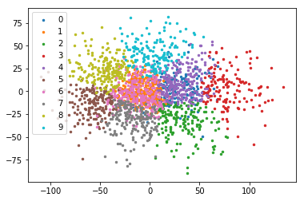

```python
u_labels = np.unique(points)
for i in u_labels:
    plt.scatter(reduced_data.T[points == i , 0] , reduced_data.T[points == i , 1] , s=6, label = i)
plt.legend()
plt.show()
```

```python
from collections import Counter
Counter(points)
```

```
Counter({7: 193,
         4: 233,
         2: 165,
         1: 367,
         8: 201,
         6: 251,
         5: 192,
         3: 153,
         9: 159,
         0: 149})
```

```python
centroid_idxs = np.zeros(10)
max_face_idxs = np.zeros(10)
for i in range(len(centroids)):
    dist = np.empty(points.shape)
    for j in range(len(points)):
        if points[j] != i:
            dist[j] = 0
        else:
            dist[j] = distance.euclidean(centroids[i],reduced_data[:,j])
    dist = np.ma.masked_where(dist==0,dist)
    centroid_idxs[i] = np.argmin(dist)
    max_face_idxs[i] = np.argmax(dist)
print(centroid_idxs)
print(max_face_idxs)
```

```
[ 803. 1978.  444. 1888. 1374. 1032. 1274.  198. 1255.  896.]
[1090. 1881.  590.  252.  705. 1231. 1989. 1543. 1682. 1606.]
```

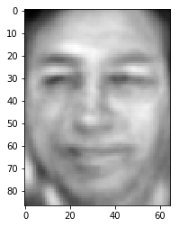

```python
##
## Problem 4 Part 6
##

# reconstruct

Zk = np.array(X_people@sorted_eigenvectors[:,:100])

finalk = Zk @ sorted_eigenvectors[:,:100].T

#reconstruction = (final[0,:] * std) + mean
reconstructionk = finalk[803,:]

plt.imshow(np.reshape(reconstructionk,(87,65)), cmap=cm.gray)
plt.show()
```

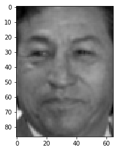

```python
plt.imshow(np.reshape(X_people[803],(87,65)), cmap=cm.gray)
plt.show()
```

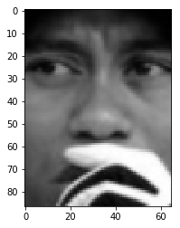

```python
plt.imshow(np.reshape(X_people[1090],(87,65)), cmap=cm.gray)
plt.show()
```

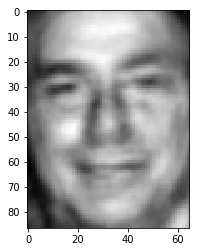

```python
# reconstruct

Zk = np.array(X_people@sorted_eigenvectors[:,:100])

finalk = Zk @ sorted_eigenvectors[:,:100].T

#reconstruction = (final[0,:] * std) + mean
reconstructionk = finalk[1978,:]

plt.imshow(np.reshape(reconstructionk,(87,65)), cmap=cm.gray)
plt.show()
```

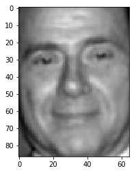

```python
plt.imshow(np.reshape(X_people[1978],(87,65)), cmap=cm.gray)
plt.show()
```

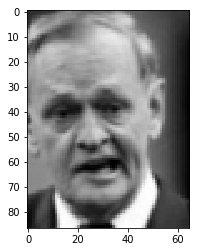

```python
plt.imshow(np.reshape(X_people[1881],(87,65)), cmap=cm.gray)
plt.show()
```

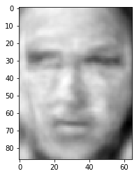

```python
# reconstruct

Zk = np.array(X_people@sorted_eigenvectors[:,:100])

finalk = Zk @ sorted_eigenvectors[:,:100].T

#reconstruction = (final[0,:] * std) + mean
reconstructionk = finalk[444,:]

plt.imshow(np.reshape(reconstructionk,(87,65)), cmap=cm.gray)
plt.show()
```

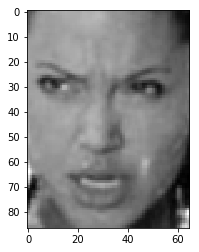

```python
plt.imshow(np.reshape(X_people[444],(87,65)), cmap=cm.gray)
plt.show()
```

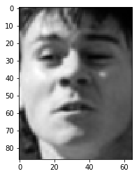

```python
plt.imshow(np.reshape(X_people[590],(87,65)), cmap=cm.gray)
plt.show()
```

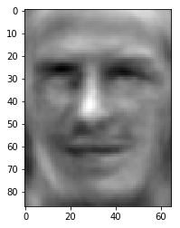

```python
# reconstruct

Zk = np.array(X_people@sorted_eigenvectors[:,:100])

finalk = Zk @ sorted_eigenvectors[:,:100].T

#reconstruction = (final[0,:] * std) + mean
reconstructionk = finalk[1888,:]

plt.imshow(np.reshape(reconstructionk,(87,65)), cmap=cm.gray)
plt.show()
```

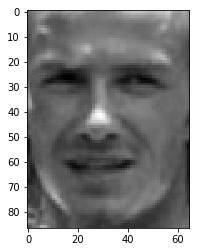

```python
plt.imshow(np.reshape(X_people[1888],(87,65)), cmap=cm.gray)
plt.show()
```

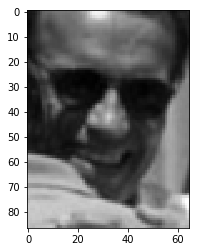

```python
plt.imshow(np.reshape(X_people[252],(87,65)), cmap=cm.gray)
plt.show()
```

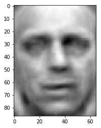

```python
# reconstruct

Zk = np.array(X_people@sorted_eigenvectors[:,:100])

finalk = Zk @ sorted_eigenvectors[:,:100].T

#reconstruction = (final[0,:] * std) + mean
reconstructionk = finalk[1374,:]

plt.imshow(np.reshape(reconstructionk,(87,65)), cmap=cm.gray)
plt.show()
```

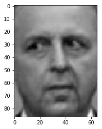

```python
plt.imshow(np.reshape(X_people[1374],(87,65)), cmap=cm.gray)
plt.show()
```

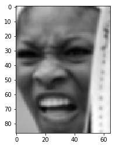

```python
plt.imshow(np.reshape(X_people[705],(87,65)), cmap=cm.gray)
plt.show()
```

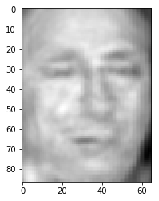

```python
# reconstruct

Zk = np.array(X_people@sorted_eigenvectors[:,:100])

finalk = Zk @ sorted_eigenvectors[:,:100].T

#reconstruction = (final[0,:] * std) + mean
reconstructionk = finalk[1032,:]

plt.imshow(np.reshape(reconstructionk,(87,65)), cmap=cm.gray)
plt.show()
```

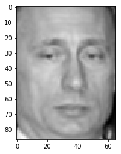

```python
plt.imshow(np.reshape(X_people[1032],(87,65)), cmap=cm.gray)
plt.show()
```

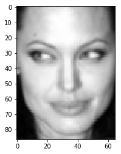

```python
plt.imshow(np.reshape(X_people[1231],(87,65)), cmap=cm.gray)
plt.show()
```

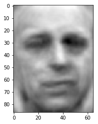

```python
# reconstruct

Zk = np.array(X_people@sorted_eigenvectors[:,:100])

finalk = Zk @ sorted_eigenvectors[:,:100].T

#reconstruction = (final[0,:] * std) + mean
reconstructionk = finalk[1274,:]

plt.imshow(np.reshape(reconstructionk,(87,65)), cmap=cm.gray)
plt.show()
```

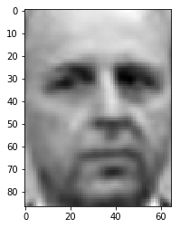

```python
plt.imshow(np.reshape(X_people[1274],(87,65)), cmap=cm.gray)
plt.show()
```

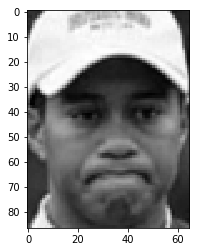

```python
plt.imshow(np.reshape(X_people[1989],(87,65)), cmap=cm.gray)
plt.show()
```

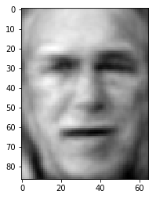

```python
# reconstruct

Zk = np.array(X_people@sorted_eigenvectors[:,:100])

finalk = Zk @ sorted_eigenvectors[:,:100].T

#reconstruction = (final[0,:] * std) + mean
reconstructionk = finalk[198,:]

plt.imshow(np.reshape(reconstructionk,(87,65)), cmap=cm.gray)
plt.show()
```

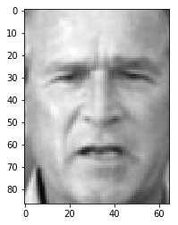

```python
plt.imshow(np.reshape(X_people[198],(87,65)), cmap=cm.gray)
plt.show()
```

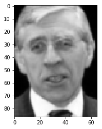

```python
plt.imshow(np.reshape(X_people[1543],(87,65)), cmap=cm.gray)
plt.show()
```

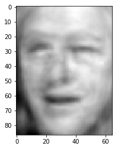

```python
# reconstruct

Zk = np.array(X_people@sorted_eigenvectors[:,:100])

finalk = Zk @ sorted_eigenvectors[:,:100].T

#reconstruction = (final[0,:] * std) + mean
reconstructionk = finalk[1255,:]

plt.imshow(np.reshape(reconstructionk,(87,65)), cmap=cm.gray)
plt.show()
```

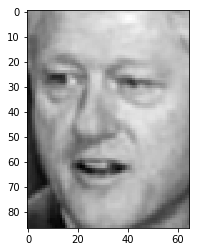

```python
plt.imshow(np.reshape(X_people[1255],(87,65)), cmap=cm.gray)
plt.show()
```

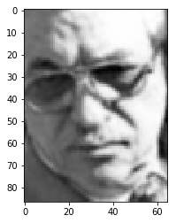

```python
plt.imshow(np.reshape(X_people[1682],(87,65)), cmap=cm.gray)
plt.show()
```

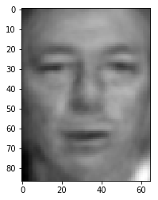

```python
# reconstruct

Zk = np.array(X_people@sorted_eigenvectors[:,:100])

finalk = Zk @ sorted_eigenvectors[:,:100].T

#reconstruction = (final[0,:] * std) + mean
reconstructionk = finalk[896,:]

plt.imshow(np.reshape(reconstructionk,(87,65)), cmap=cm.gray)
plt.show()
```

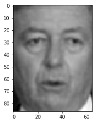

```python
plt.imshow(np.reshape(X_people[896],(87,65)), cmap=cm.gray)
plt.show()
```

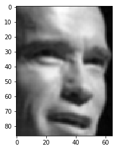

```python
plt.imshow(np.reshape(X_people[1606],(87,65)), cmap=cm.gray)
plt.show()
```